# Práctica 3: Metaheurísticas basadas en poblaciones - Algoritmos Genéticos

## Instrucciones

Esto es **Jupyter Notebook**, un documento que integra código Python en un archivo Markdown. Esto nos permite ir ejecutando celdas de código poco a poco, así como generar automáticamente un informe bien formateado de la práctica.

Puedes añadir una celda con el botón **"Insert"** de la barra de herramentas, y cambiar su tipo con **"Cell > Cell Type"**

Para ejecutar una celda de código, la seleccionaremos y pulsaremos el botón **"▶ Run"** de la barra de herramentas. Para pasar el documento a HTML, seleccionaremos **"File > Download as > HTML (.html)"**

Sigue este guión hasta el final. Ejecuta el código proporcionado paso a paso comprendiendo lo que estás haciendo y reflexionando sobre los resultados. Habrá preguntas intercaladas a lo largo del guión, responde a todas ellas en la sección reservada para ese fin: **"Respuestas a los cuestionarios"**. Por favor, no modifiques ninguna linea de código excepto cuando se te pida explícitamente.

No olvides insertar tu **nombre y apellidos** en la celda superior.

IMPORTANTE: Escribe el código de tu o tus soluciones/respuestas en las celdas que se indican para ello. Además, a lo largo de la práctica se plantearán varias preguntas que debéis responder en la parte inferior del documento, incluyendo las celdas que veáis necesarias (si hacéis referencia a partes concretas de vuestro código, etc) para reponder a ellas.

## Entrega de la práctica

La fecha límite de entrega será la indicada en el Campus Virtual. La entrega consistirá de un único archivo comprimido con nombre `APELIDOS_NOME_Geneticos.zip` que contenga los seguientes ficheros:

- `APELIDOS_NOME_Geneticos.html`: Archivo HTML fruto de la exportación del presente Notebook, con las preguntas respondidas al final del documento.
- `APELIDOS_NOME_Geneticos.ipynb`: Archivo fuente Jupyter Notebook.
- Archivo de datos de los problema utilizados en la resolución.

## Preliminares adicionales sobre Python

Para esta práctica, te sugerimos algunas funciones de paquetes que pueden resultarte útiles en la realización de esta práctica.

Has visto que cuando realizas laboratorios y pruebas para ajustar parámetros resulta necesario tener una estimación del tiempo invertido en la ejecución. Eso ayuda a valorar el balance del tiempo computacional frente a la inclusión de valores de parámetros en el laboratorio. En ese sentido, puede resultar conveniente añadir barras de progreso que además te permitan visualizar el progreso de resolución de las iteraciones. Para ese propósito podéis hacer uso del paquete `tqdm` (https://tqdm.github.io/).

Puedes ver ejemplos en detalle descritos en https://towardsdatascience.com/progress-bars-for-python-with-tqdm-4dba0d4cb4c

Veámos un ejemplo ilustrativo aquí.

```python
# solo debes importarlo una vez en el notebook.
# fíjate que estamos importando del paquete tqdm.notebook para que incorpore los decoradores compatibles en Jupyter
# (en Python podrías importar simplemente desde el paquete tdqm)
from tqdm.notebook import trange, tqdm
```

`tqdm` permite añadir una barra de progreso que informe sobre el tiempo y el paso de iteraciones. En el ejemplo, la variable `nit` son el número de iteraciones a realizar y para conseguir que se visualize el progreso se pasa a `tqdm` un iterador de rango.

```python
from random import randint

heads = 0
tails = 0
nit=1000000
for i in tqdm(range(nit), desc='Coin Flip Progress'):
    toss = randint(0, 1)
    if toss == 0:
        heads += 1
    else:
        tails += 1
```

El paquete nos ofrece la posibilidad combinar `tdqm(range(NUM_IT))` en una única función, llamada `trange(NUM_IT)`. Veamos su funcionamiento en el siguiente ejemplo, que muestra también cómo podemos hacer cuando necesitamos llevar cuenta del progreso en bucles anidados.

```python
num_games = 3

for game in trange(num_games, desc='Overall Progress'):
    heads = 0
    tails = 0
    nit=1000000
    for j in trange((nit), desc=f'Game {game+1} Progress'):
        toss = randint(0, 1)
        if toss == 0:
            heads += 1
        else:
            tails += 1

    print(f'Heads: {heads}, Tails: {tails}')
```

```
Heads: 500481, Tails: 499519
```

```
Heads: 499999, Tails: 500001
```

```
Heads: 499192, Tails: 500808
```

Aprovechamos para recordarte que puedes utilizar semillas en la generación de secuencias de números aleatorios para hacer determinista y más verificable tu implementación.

```python
import random
import time
```

```python
# este vector será aleatorio si no habíamos establecido una semilla previamente.
# Podríamos tener incluso una semilla basada en el tiempo actual para forzar que se aleatorice
# si ejecutamos esta celda múltiples veces
random.seed(time.time())

vector_aleatorio = [ random.randint(1, 10) for i in range(1,10) ]
print ("vector aleatorio ", vector_aleatorio)

# aquí establecemos una semilla totalmente fija
# que no depende del tiempo y por tanto está bajo nuestro control
semilla = 123456
random.seed (semilla)

# este viene determinado por la semilla
vector_aleatorio = [ random.randint(1, 10) for i in range(1,10) ]
print ("vector aleatorio ", vector_aleatorio)

# y ahora somos capaces de generar la misma serie "aleatoria"
random.seed (semilla)
vector_aleatorio = [ random.randint(1, 10) for i in range(1,10) ]
print ("vector aleatorio igual que el anterior", vector_aleatorio)
```

```
vector aleatorio  [7, 10, 1, 5, 6, 5, 6, 8, 9]
vector aleatorio  [5, 1, 3, 1, 2, 1, 5, 1, 2]
vector aleatorio igual que el anterior [5, 1, 3, 1, 2, 1, 5, 1, 2]
```

Esto puede ser útil para verificar que siempre obtienes los mismos resultados ante el mismo conjunto de entradas.

## El Problema del Viajante de Comercio (VC) con Algoritmos Genéticos

El objetivo de esta práctica es modelar e implementar un agente inteligente que sea capaz de resolver el problema del VC mediante la metaheurística (MH) de poblaciones conocida como Algoritmo Genético (GA, del inglés *Genetic Algorithm*). Para ello, realizarás una implementación del algoritmo básico visto en la clase expositiva y valorarás si la introducción de modificaciones en el diseño del algoritmo te permite mejorar la calidad de las soluciones alcanzadas.

### Definición del problema de Viajante de Comercio (VC)

La definición del problema sigue la descripción ya vista en las prácticas anterior, en la que se disponía de una represetación del problema mediante un grafo ponderado. Así que, en primer lugar importa el módulo Python que acompaña esta práctica, que ya trae las funciones de apoyo como la clase `Localizaciones` que implementaba la carga de datos y que utilizaba una matriz de adyacencia.

```python
from helpers_mod_ga import *
```

Si todo va bien, la primera distancia entre la ciudad 0 y 1 debe ser unos 55 km para el problema de las 8 ciudades gallegas.

```python
g1=Localizaciones(filename='./data/grafo8cidades.txt')
print (g1.distancia(0,1))
g2 = Localizaciones(filename='./data/US120.txt')
print (g2.distancia(0,1))
```

```
55.88273580792048
1596.5471930797373
```

## P3.1: Implementación básica de Algoritmo Genético

Implementa un algoritmo genético básico para resolver el problema del VC, siguiendo la descripción algorítmica de la MH vista en la clase expositiva.

Ten en cuenta las siguientes consideraciones de diseño para completar esta implementación básica:

- Representación de las soluciones: representación de orden (permutaciones) comenzando y finalizando en la ciudad 0.
- Población inicial: inicialización completamente aleatoria de la población inicial, que sean permutaciones válidas.
- Operador de cruce: Order Crossover (OX). La función/método que se encargue de hacer el cruce ordenado debe aceptar como parámetros la probabilidad de cruce (por defecto, establecida a pc=0.95), los dos puntos de corte así como los cromosomas sobre los que actuar.
- Operador de mutación: se utilizará el operador de intercambio, aplicado con una probabilidad de mutación. Vuestra implementación debe manejar dos variantes de esta función:
  - Mutación individual: solo se aplica la mutación, si procede, sobre un único gen en el cromosoma. La probabilidad de mutación por defecto se establece pm=0.25. Esta función debería recibir el índice del gen sobre el que actuar además de la probabilidad de mutación y el cromosoma original.
  - Mutación cromosómica: se aplica la mutación contemplando todo el cromosoma, de forma que individualmente puede mutar cada gen de manera independiente según una probabilidad de mutación, establecida por defecto a pm=0.01.
- El reemplazo de la generación debe seguir un modelo de reemplazo generacional con elitismo. En particular, tu implementación debe disponer de dos variantes de la función de reemplazo:
  - mitades: haz que la mitad de la población resultante del reemplazo provenga de la generación actual mientras que la otra mitad provenga de los descendientes, tomando en ambos casos los mejores individuos.
  - elitismo "elite=2": de esta forma, hay que mantener los 2 mejores individuos de la generación actual/ancestros; mientras que el resto provienen de entre los mejores hijos. La función de reemplazo debería parametrizar "elite".

Ambas variantes deben recibir como parámetro la lista de cromosomas de las poblaciones ascentros e hijos generados y retornar la población resultante.

- Condición de parada simple basado en un número de iteraciones máximo pasado como parámetro.
- La implementación debe ser completamente parametrizable, de forma que todos los componentes susceptibles de ser ajustados mediante parámetros deberían puedan ser establecidos en cada ejecución/problema.

Lanza varias ejecuciones para verificar que puede resolver el problema con los siguientes grafos de ejemplo:

- grafo 8 ciudades gallegas (`data/grafo8cidades.txt`), con una población de 2 individuos y 150 iteraciones.
- grafo 120 ciudades estadounidenses (`data/US120.txt`), con una población de 32 individuos y 500 iteraciones.

Si no te convergiera, prueba a extender el número de iteraciones o variar parámetros como la probabilidad de mutación.

```python
import matplotlib.pyplot as plt

#Representacion de soluciones
def representar(locaciones, sol):
    fig = plt.figure()
    ax = fig.add_subplot()

    for i in range(0, locaciones.nciudades):
        ciudad = locaciones.tablaciudades[i][::-1]
        ax.plot(ciudad[0],ciudad[1],"or")

    for i in range(0, len(sol)-1):
        ciudad1 = locaciones.tablaciudades[sol[i]][::-1]
        ciudad2 = locaciones.tablaciudades[sol[i+1]][::-1]
        ax.plot([ciudad1[0],ciudad2[0]],[ciudad1[1],ciudad2[1]])

    if len(sol) > 0:
        c0 = locaciones.tablaciudades[0][::-1]
        c1 = locaciones.tablaciudades[sol[0]][::-1]
        c2 = locaciones.tablaciudades[sol[len(sol)-1]][::-1]
        ax.plot([c0[0], c1[0]], [c0[1], c1[1]])
        ax.plot([c2[0], c0[0]], [c2[1], c0[1]])

    plt.show()
```

```python
#BIEN
#solucion inicial
def genera_solucion_inicial(g):
    sol = [x for x in range(1,g.nciudades)]
    random.shuffle(sol)
    return sol

#poblacion inicial
def genera_poblacion_inicial(g, tamano):
    return [genera_solucion_inicial(g) for i in range(tamano)]

#duplicar la poblacion
def duplica(g, poblacion):
    return [sol.copy() for sol in poblacion]
```

```python
#BIEN
#funcion de coste
def coste(g, sol):
    s = g.distancia(0,sol[0])#desde el 0 al primer punto de la solucion
    for i in range(0,len(sol)-1):
        s+= g.distancia(sol[i],sol[i+1])
    s+= g.distancia(sol[len(sol)-1],0)#desde el final hasta la ciudad 0
    return s
```

```python
def cruce(parent1, parent2, p1, p2, probabilidad=0.95):
    #Primero evaluamos la probabilidad de cruzar
    if random.uniform(0,1)>probabilidad:
        return parent1, parent2

    hijo1 = [-1 for i in range(len(parent1))]
    hijo2 = [-1 for i in range(len(parent1))]

    if p1 > p2:
        p1, p2 = p2, p1

    hijo1[p1:p2] = parent2[p1:p2]
    hijo2[p1:p2] = parent1[p1:p2]

    j = 0
    k=0
    for i in range(len(hijo1)):
        if parent1[(p2 + i) % len(hijo1)] not in hijo1:
            hijo1[(p2 + j) % len(hijo1)] = parent1[(p2 + i) % len(hijo1)]
            j+= 1

        if parent2[(p2 + i) % len(hijo2)] not in hijo2:
            hijo2[(p2 + k) % len(hijo2)] = parent2[(p2 + i) % len(hijo2)]
            k+= 1




    return [hijo1, hijo2]
cruce([1, 2, 3, 4, 5, 6, 7], [1, 5, 4, 7, 6, 2, 3],2,5,0.95)
```

```
[[3, 5, 4, 7, 6, 1, 2], [7, 6, 3, 4, 5, 2, 1]]
```

```python
random.seed(123456)
cruce([1,2,3,4,5,6,7,8,9], [9,3,7,8,2,6,5,1,4], 3, 7, 0.95)
```

```
[[3, 4, 7, 8, 2, 6, 5, 9, 1], [3, 8, 2, 4, 5, 6, 7, 1, 9]]
```

```python
#([3, 5, 4, 7, 6, 1, 2], [7, 6, 3, 4, 5, 2, 1])
cruce([1, 2, 3, 4, 5, 6, 7], [1, 5, 4, 7, 6, 2, 3],2,5, 0.95)
```

```
[[3, 5, 4, 7, 6, 1, 2], [7, 6, 3, 4, 5, 2, 1]]
```

```python
#BIEN
#hacer las parejas de padres
def parejas_padres(g, poblacion, tam_torneo=2):
    padres = []
    for i in range(0,tam_torneo):
        competicion = random.sample(poblacion, tam_torneo)
        mejor_padre = min(competicion, key = lambda x: coste(g, x))
        padres.append(mejor_padre)

    return padres
```

```python
def puntos_corte(cromosoma):
    punto_corte1, punto_corte2 = sorted(random.sample(range(0, len(cromosoma)), 2))
    while punto_corte1 == punto_corte2:
        punto_corte2 = random.sample(range(0, len(cromosoma)), 1)
    return punto_corte1, punto_corte2
```

```python
#BIEN
#mutacion
def mutacion_individual(cromosoma, indice_gen, prob_mutacion=0.25):
    # Verificar la probabilidad de mutación
    if random.random() <= prob_mutacion:
        # Generar un índice aleatorio diferente al índice del gen actual
        nuevo_indice = random.randint(0,len(cromosoma)-1)
                # Intercambiar los valores de los genes en los índices seleccionados
        cromosoma[indice_gen], cromosoma[nuevo_indice] = cromosoma[nuevo_indice], cromosoma[indice_gen]

    return cromosoma
```

```python
#BIEN
def mutacion_cromosomica(cromosoma, prob_mutacion=0.01):
    # Aplicar la mutación a cada gen del cromosoma según la probabilidad de mutación
    for i in range(len(cromosoma)):
        if random.random()<= prob_mutacion:
            #cromosoma = mutacion_individual(cromosoma, i, prob_mutacion)
            gen = random.randint(0,len(cromosoma)-1)
            cromosoma[i], cromosoma[gen]= cromosoma[gen], cromosoma[i]
    return cromosoma
```

```python
#asociarle el caste de cada
def pob_costes(g, poblacion):
    duplas = [(sol, coste(g, sol)) for sol in poblacion]
    return sorted(duplas, key=lambda d: d[1])
```

```python
#BIEN
def reemplazo_mitades(g, poblacion_actual, descendientes):
    poblacion = sorted(poblacion_actual, key = lambda x: coste(g, x))
    hijos = sorted(descendientes, key = lambda x: coste(g, x))
    nuevapoblacion = poblacion[:int(len(poblacion)/2)] + hijos[:int(len(hijos)/2)]
    return nuevapoblacion
```

```python
#reemplazo elitismo
def reemplazo_elitismo(g, generacion_actual, descendientes, elite=2):
    poblacion = sorted(generacion_actual, key=lambda x: coste(g,x))

    hijos = sorted(descendientes, key=lambda x: coste(g,x))
    generacion = poblacion[:elite] + hijos[:(len(hijos)-elite)]
    return generacion
```

```python
p1=[[1, 2, 3, 4, 5, 6, 7], [1, 3, 2, 4, 5, 6, 7], [1, 2, 3, 4, 6, 5, 7], [1, 2, 3, 4, 5, 7,6], [1, 2, 4,3, 6, 5, 7], [1, 2, 3, 5,4, 7,6]]
p2=[[1,4,5,6,7,2,3], [1, 3, 2, 4, 5, 6, 7], [7,6,5,4,3,2,1], [1, 2, 3, 4,6,7,5], [7,6,4,5,3,2,1], [2,1, 3, 4,6,7,5]]
reemplazo_elitismo(g1,p1,p2)
```

```
[[1, 2, 3, 4, 5, 6, 7],
 [1, 2, 3, 4, 5, 7, 6],
 [7, 6, 5, 4, 3, 2, 1],
 [1, 3, 2, 4, 5, 6, 7],
 [7, 6, 4, 5, 3, 2, 1],
 [1, 2, 3, 4, 6, 7, 5]]
```

```python
def order_crossover(cromosoma1, cromosoma2, punto_corte1 = None, punto_corte2 = None, pc = 0.95):
    if punto_corte1 is None:
        punto_corte1 = random.randint(0, len(cromosoma1) - 1)
    if punto_corte2 is None:
        punto_corte2 = random.randint(0, len(cromosoma1) - 1)

    if punto_corte1 > punto_corte2:
        punto_corte1 = punto_corte2
        punto_corte2 = punto_corte1

    segmento1_parte1 = cromosoma1[punto_corte1:punto_corte2]
    segmento1_parte2 = []
    segmento2_parte1 = []
    segmento2_parte2 = cromosoma2[punto_corte1:punto_corte2]

    for i in range(punto_corte2, len(cromosoma2)):
        if cromosoma2[i] not in segmento1_parte1:
            segmento1_parte2.append(cromosoma2[i])
    for i in range(0, punto_corte2):
        if cromosoma2[i] not in segmento1_parte1:
            segmento1_parte2.append(cromosoma2[i])
    hijo1 = segmento1_parte2[(len(cromosoma2) - punto_corte2):] + segmento1_parte1 + segmento1_parte2[0:(len(cromosoma2) - punto_corte2)]
    for i in range(punto_corte2, len(cromosoma1)):
        if cromosoma1[i] not in segmento2_parte2:
            segmento2_parte1.append(cromosoma1[i])
    for i in range(0, punto_corte2):
        if cromosoma1[i] not in segmento2_parte2:
            segmento2_parte1.append(cromosoma1[i])
    hijo2 = segmento2_parte1[(len(cromosoma1) - punto_corte2):] + segmento2_parte2 + segmento2_parte1[0:(len(cromosoma1) - punto_corte2)]

    return [hijo1, hijo2]
```

```python
def algoritmo_genetico( g, tam_pob=2, iteraciones = 350, mutacion = 'individual', reemplazo='elitista', pm = 0.25):
    poblacion = genera_poblacion_inicial(g,tam_pob)
    for i in range(iteraciones):
        padres = parejas_padres(g, poblacion,2)
        p1,p2 = puntos_corte(padres[0])
        hijos = order_crossover(padres[0],padres[1], p1,p2,0.95)

        for _ in range(tam_pob //2 ):
            padres = parejas_padres(g, poblacion,2)
            p1,p2 = puntos_corte(padres[0])
            descendientes = order_crossover(padres[0],padres[1], p1,p2,0.95)
            #print(descendientes)
            if(mutacion == 'individual'):
                for desc in range(0,len(descendientes)):
                    indice = random.randint(0, len(descendientes)-1)
                    descendientes[desc]= mutacion_individual(descendientes[desc],indice, pm)

            if(mutacion == 'cromosomica'):
                for desc in range(0,len(descendientes)):
                    descendientes[desc] = mutacion_cromosomica(descendientes[desc],pm)

            for j in range(0,len(descendientes)):
                hijos.append(descendientes[j])

        if(reemplazo == 'mitades'):
            poblacion = reemplazo_mitades(g, poblacion, hijos)
        elif(reemplazo == 'elitista'):
            poblacion = reemplazo_elitismo(g, poblacion, hijos)

    mejor_solucion = min(poblacion, key = lambda cromosoma: coste(g, cromosoma))

    return mejor_solucion, coste(g, mejor_solucion)
```

```
381.6699617675482
```

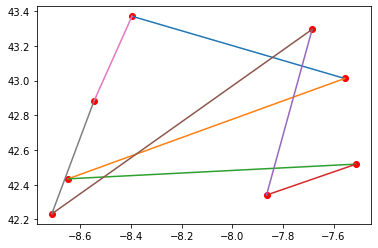

```python
print(coste(g1,[1,2,3,4,5,6,7]))
sol = genetico(g1, 2, 150, 0.25)
representar(g1, sol[0])
```

❓ **Pregunta 1**. Explica brevemente los detalles relevantes de tu código para entender tu implementación (p.ej., estructura de tu código, funciones, implementación de operadores, etc.). ¿Cuál es el mecanismo de selección escogido para tu implementación? Explica también cómo has verificado tu implementación.

## P3.2: Laboratorio

Como toda metaheurística, resulta crucial conocer cómo afecta en términos prácticos los parámetros del algoritmo y los operadores desarrollados. Estudia el comportamiento del algoritmo implementado para resolver VC atendiendo a las siguientes cuestiones.

❓ **Pregunta 2**. Realiza el estudio de la calidad de la solución variando el tamaño de la población: 1, 2, 4, 8, 16, 32, 64... ¿Qué valor recomendarías para el problema de las 120 ciudades? ¿Por qué? Ten en cuenta que tienes dos variantes del mecanismo de reemplazo.

❓ **Pregunta 3**. Ahora realiza un estudio similar variando la probabilidad de mutación en el rango 0, ..., 0.95 en pasos de 0.05~0.10. ¿Qué valor recomendarías para este parámetro? ¿Por qué? Ten en cuenta que tienes dos variantes del mecanismo de mutación.

❓ **Pregunta 4**. Finalmente realiza un estudio variando el número de iteraciones máximas en el rango de 50 a 1000, considerando un paso variable o adaptativo a conveniencia. ¿Qué valor recomendarías para este parámetro? ¿Por qué? Realiza una discusión reflexionando sobre los resultados conjuntos de estos tres parámetros.

Apoya todas tus respuestas en datos-gráficos resultantes de tus estudios, reportados de forma que sea fácil de comparar/contrastar.

Importante: además de la calidad de la soluciones obtenidas, se recomienda medir tiempos para tomar medidas operativas sobre el número de repeticiones que permitan realizar promedios (se recomienda no más de 10 si se ralentiza mucho) y prescindir de manera razonada de valores en las series de ejecución que no sean computacionalmente rentables/viables con tu implementación/ordenador (p.ej., tamaños de población elevados pueden tomar mucho tiempo para resolver).

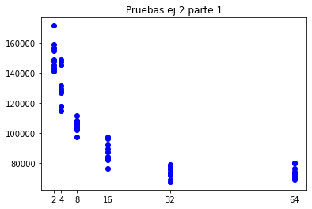

```python
#Ejercicio 2 - tamaño de poblacion - dos variantes reemplazo mitades y mutacion individual
tests = 10
poblaciones= [2,4,8,16,32,64]

fig = plt.figure()
ax = fig.add_subplot(111, projection='rectilinear')
ax.set_title("Pruebas ej 2 parte 1")
ax.set_xticks(poblaciones)

for pob in tqdm(poblaciones, leave=None):
    for i in tqdm(range(0, tests), leave=None):
        ax.plot(pob, algoritmo_genetico(g2, pob)[1], "bo")
plt.show()
```

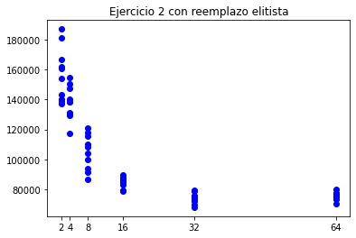

```python
tests = 10
poblaciones= [2,4,8,16,32,64]

fig = plt.figure()
ax = fig.add_subplot(111, projection='rectilinear')
ax.set_title("Ejercicio 2 con reemplazo elitista")
ax.set_xticks(poblaciones)

for pob in tqdm(poblaciones, leave=None):
    for i in tqdm(range(0, tests), leave=None):
        ax.plot(pob, algoritmo_genetico(g2, pob, reemplazo = 'elitista')[1], "bo")
plt.show()
```

```python
def pruebas2(g, numTest=10, numIteracion=500):
    poblaciones = [2,4,8,16,32,64,128]
    fig, ax = plt.subplots(figsize=(16,10))

    for reemplazo in ['mitades', 'elitista']:
        for mutacion in ['individual','cromosomica']:
            resultados=[]

            for poblacion in poblaciones:
                results = []
                for _ in tqdm(range(numTest),desc=f'Tamaño Población {pob}, Mutacion: {mutacion}, Reemplazo {reemplazo}'):
                    solucion = algoritmo_genetico(g, poblacion, numIteracion,mutacion,reemplazo)
                    results.append(solucion[1])
                resultados.append(results)
            resultados = np.array(resultados)
        plt.plot(poblacion, resultados, label=f'{mutacion} - {reemplazo}')

        media = np.mean(resultados, axis=1)
        desv = np.std(resultados, axis=1)
        maximo = np.max(resultados, axis=1)
        minimo = np.min(resultados, axis=1)
        print(f'Media:{np.mean(media)}')
        print(f'Desv tipica:{np.mean(desv)}')
        print(f'Maximo:{np.mean(maximo)}')
        print(f'Minimo:{np.mean(minimo)}')
        ax.plot(poblaciones, media, label=f'{reemplazo}, {mutacion}')

    ax.legend()
    ax.set_xlabel('Tamaño de población')
    ax.set_ylabel('Coste')
    ax.set_title(f'Coste en función del tamaño')
    ax.set_xticks(poblaciones)
    ax.set_xticklabels([f'{val:.2f}' for val in poblaciones])
    plt.show()
```

```
Coste máximo con mutacion individual y reemplazo mitades: 154222.9393439943
Coste mínimo con mutacion individual y reemplazo mitades: 55875.434311585304
Media coste con mutacion individual y reemplazo mitades: 98481.76569991051
Desviación típica coste con mutacion individual y reemplazo mitades: 34500.40248281622
```

```
Coste máximo con mutacion cromosomica y reemplazo mitades: 115874.17234311327
Coste mínimo con mutacion cromosomica y reemplazo mitades: 64134.124525652485
Media coste con mutacion cromosomica y reemplazo mitades: 84466.0467328504
Desviación típica coste con mutacion cromosomica y reemplazo mitades: 16674.938487298867
```

```
Coste máximo con mutacion individual y reemplazo elitismo: 183214.27150382442
Coste mínimo con mutacion individual y reemplazo elitismo: 163215.1625242093
Media coste con mutacion individual y reemplazo elitismo: 172292.71326727918
Desviación típica coste con mutacion individual y reemplazo elitismo: 6237.534149662429
```

```
Coste máximo con mutacion cromosomica y reemplazo elitismo: 183663.72717199492
Coste mínimo con mutacion cromosomica y reemplazo elitismo: 161901.52496016468
Media coste con mutacion cromosomica y reemplazo elitismo: 172317.0337702503
Desviación típica coste con mutacion cromosomica y reemplazo elitismo: 6963.797134180368
```

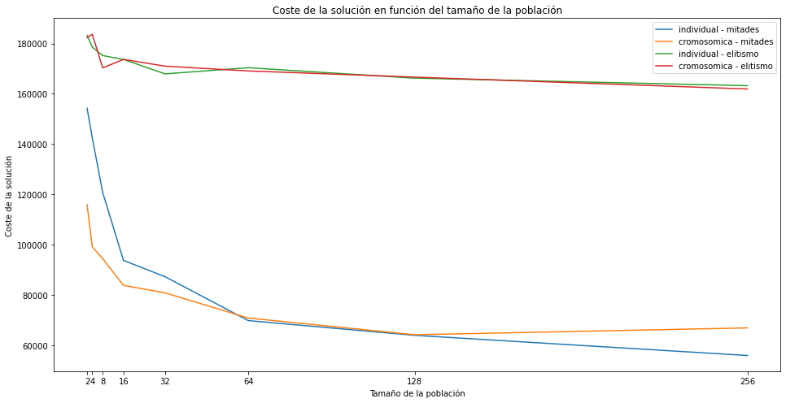

```python
def pruebas2(grafo, itPruebas = 10, iteracionesAlgoritmo = 500):
    poblacion = [2, 4, 8, 16, 32, 64, 128, 256]

    fig, ax = plt.subplots(figsize=(16, 8))

    for reemplazo in ['mitades', 'elitismo']:
        for mutacion in ['individual', 'cromosomica']:
            resultado = []

            for pob in poblacion:
                resultadoAux = []
                for _ in tqdm(range(itPruebas), desc=f'Tamaño Población {pob}, Mutacion: {mutacion}, Reemplazo {reemplazo}'):
                    solucion = algoritmo_genetico(grafo, pob, iteracionesAlgoritmo, mutacion, reemplazo)
                    resultadoAux.append(solucion[1])

                resultado.append(sum(resultadoAux) / len(resultadoAux))

            plt.plot(poblacion, resultado, label=f'{mutacion} - {reemplazo}')
            plt.legend()
            plt.xlabel('Tamaño de la población')
            plt.ylabel('Coste de la solución')
            plt.title('Coste de la solución en función del tamaño de la población')

            print(f"Coste máximo con mutacion {mutacion} y reemplazo {reemplazo}: {max(resultado)}")
            print(f"Coste mínimo con mutacion {mutacion} y reemplazo {reemplazo}: {min(resultado)}")
            print(f"Media coste con mutacion {mutacion} y reemplazo {reemplazo}: {sum(resultado) / len(resultado)}")
            print(f"Desviación típica coste con mutacion {mutacion} y reemplazo {reemplazo}: {np.std(resultado)}")

    ax.set_xticks(poblacion)
    ax.set_xticklabels(poblacion)
    plt.show()

pruebas2(g2, 5, 250)
```

[output not shown]

[figure not shown]

```python
pruebas2(g2,5,350)
```

```python
import matplotlib.pyplot as plt
import numpy as np
def prueba3(g, numTest=10, numIteracion=500):
    tamano = 64
    probabilidades = np.arange(0,1,0.05)

    fig, ax = plt.subplots(figsize=(16,10))

    for mutacion in ['individual','cromosomica']:
        resultados = []
        for probabilidad in probabilidades:
            results = []
            for _ in tqdm(range(numTest), desc=f'Probabilidad de mutación {probabilidad}, Reemplazo mitades, Mutación {mutacion}'):
                solucion = algoritmo_genetico(g, tamano, numIteracion, mutacion=mutacion, reemplazo='mitades', pm=probabilidad)
                results.append(solucion[1])
            resultados.append(results)
        resultados = np.array(resultados)

        media = np.mean(resultados, axis=1)
        desv = np.std(resultados, axis=1)
        maximo = np.max(resultados, axis=1)
        minimo = np.min(resultados, axis=1)
        print(f'Media:{np.mean(media)}')
        print(f'Desv tipica:{np.mean(desv)}')
        print(f'Maximo:{np.mean(maximo)}')
        print(f'Minimo:{np.mean(minimo)}')
        ax.plot(probabilidades, media, label=f'mitades, {mutacion}')

    ax.legend()
    ax.set_xlabel('Probabilidad de mutación')
    ax.set_ylabel('Coste')
    ax.set_title(f'Coste en función de la probabilidad de mutación')
    ax.set_xticks(probabilidades)
    ax.set_xticklabels([f'{val:.2f}' for val in probabilidades])
    plt.show()
```

```
Media:66613.45328162421
Desv tipica:5481.488380879646
Maximo:74408.38408681132
Minimo:59320.530887883004
```

```
Media:58764.39565190972
Desv tipica:3409.005210320008
Maximo:63331.39174909903
Minimo:53968.86386424635
```

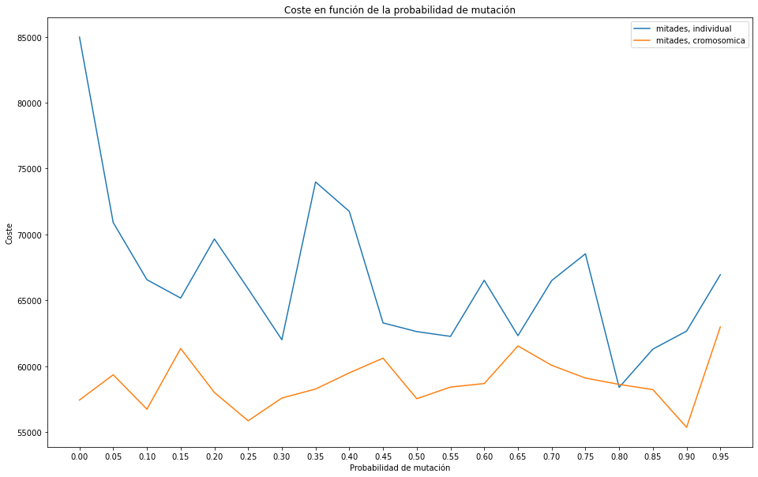

```
Cada test ha tardado:226.0142346382141
```

```python
import time
inicio_tiempo = time.time()
prueba3(g2, 5,500)
final = time.time()
print(f'Cada test ha tardado:{(final-inicio_tiempo)/5}')
```

```python
def prueba4(g, numTest=10):
    tamano = 64
    iteraciones = np.arange(50,1001,50)

    fig, ax = plt.subplots(figsize=(16,10))


    resultados = []
    for i in range(numTest):
        results = []
        for it in tqdm(iteraciones, desc=f'Iteracion {i}'):
            solucion = algoritmo_genetico(g, tamano, it, mutacion='individual', reemplazo='mitades', pm=0.25)
            results.append(solucion[1])
        resultados.append(results)
    resultados = np.array(resultados)

    media = np.mean(resultados, axis=1)
    desv = np.std(resultados, axis=1)
    maximo = np.max(resultados, axis=1)
    minimo = np.min(resultados, axis=1)
    print(f'Media:{np.mean(media)}')
    print(f'Desv tipica:{np.mean(desv)}')
    print(f'Maximo:{np.mean(maximo)}')
    print(f'Minimo:{np.mean(minimo)}')
    ax.plot(iteraciones, media, label=f'mitades, individual')

    ax.legend()
    ax.set_xlabel('Numero de iteraciones')
    ax.set_ylabel('Coste')
    ax.set_title(f'Coste en función del numero de iteraciones')
    ax.set_xticks(iteraciones)
    ax.set_xticklabels([f'{val:.2f}' for val in iteraciones])
    plt.show()
```

```python
inicio = time.time()
sol = algoritmo_genetico(g2, tam_pob = 64, iteraciones = 800, mutacion = 'cromosomica', reemplazo = 'mitades', pm = 0.9)
fin = time.time()
print(fin-inicio)
```

```
8.788054704666138
```

```python
sol[1]
```

```
56284.48180999783
```

#### Respuestas y evaluación

Recordatorio: No olvides escribir tu nombre y apellidos en la segunda celda de este documento. La respuestas a las preguntas deben venir acompañadas de las implementaciones necesarias para su respuesta.

*P3.1: Implementación básica* (5 puntos)

La implementación básica se evaluará mediante un cuestionario automático de evaluación. Este lo realizarás en la primera sesión tras la entrega, y se centrará en la resolución por tu parte de diversas cuestiones prácticas relacionadas con la implementación realizada, pudiendo ser necesaria la ejecución, adaptación y modificación de la misma.

Pregunta 1.

Independientemente del cuestionario automático de evaluación, considera siempre que las preguntas planteadas en el notebook deben ser respondidas también. Esas preguntas generales están diseñadas para formarte, y te servián para razonar y reflexionar sobre el tema, así como también para fomentar una discusión constructiva con los docentes en caso de dudas.

*P3.2: Laboratorio* (5 puntos)

Pregunta 2.

Pregunta 3.

Pregunta 4.

El informe a elaborar no debe exceder la longitud máxima de 1200 palabras.

Aclaraciones: La evaluación de esta parte se llevará a cabo en términos de la completitud y correctitud del laboratorio implementado, así como de la calidad del propio informe, que debe ser conciso y preciso, pudiendo acompañarse de gráficas y tablas que faciliten y fundamenten la explicación e argumentación. Es muy importante explicar de manera clara, precisa y fundamentada. Se reservará hasta un punto que se asignará en términos de la calidad de la mejor solución obtenida entre el conjunto de las prácticas entregadas (es por ello que no debes olvidar marcar en tu informe muy claramente cuál ha sido tu mejor solución y con qué configuración/versión).

# Laboratorio

Con la finalidad de examinar el desempeño del algoritmo genético en la solución del problema de las 120 ciudades, se ha realizado un análisis que se enfoca en diversos aspectos cruciales del algoritmo. Este estudio aborda variables fundamentales como el tamaño de la población, el método de reemplazo, la probabilidad y tipo de mutación, así como el número de iteraciones máximas.

**Pregunta 2**. Realiza el estudio de la calidad de la solución variando el tamaño de la población: 1, 2, 4, 8, 16, 32, 64... ¿Qué valor recomendarías para el problema de las 120 ciudades? ¿Por qué? Ten en cuenta que tienes dos variantes del mecanismo de reemplazo.

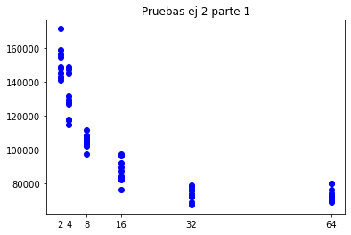

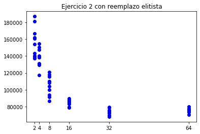

En ambas representaciones gráficas, se evidencia una marcada disminución en los costos a medida que incrementa el tamaño de la población, alcanzando las soluciones más óptimas con un tamaño de 32 o 64 individuos.

En adición a las dos variantes del mecanismo de reemplazo, se incorporan dos variantes en el algoritmo de mutación. Por ende, se procederá a estudiar las cuatro combinaciones posibles para determinar cuál sería el tamaño ideal de la población que mejor se adapte a cada configuración.

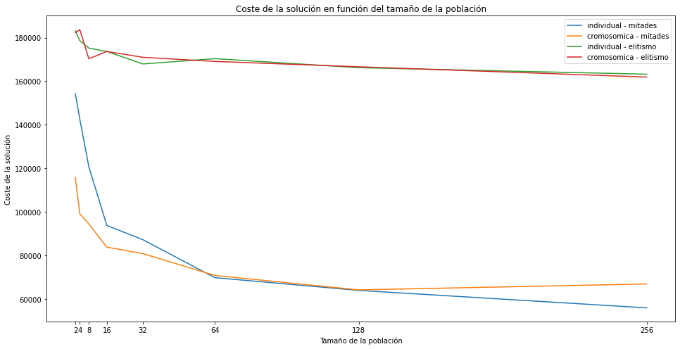

En este gráfico, se destaca una marcada disparidad entre los algoritmos de reemplazo. En el caso del algoritmo de reemplazo elitista, no se observa una reducción significativa a medida que aumenta el tamaño de la población. Por otro lado, para el algoritmo en mitades, se evidencia un notable decrecimiento en los costos hasta alcanzar un tamaño de 64. Posteriormente, se observa que, aunque podría mejorar en el caso de la mutación individual con un tamaño de 256, se mantiene generalmente estable alrededor de los 70,000 en términos de costo.

Por ende, al considerar la recomendación de un tamaño de población, teniendo en cuenta que un mayor tamaño implica más tiempo de ejecución, se sugiere optar por un tamaño de 64 o 128, dado que estos valores parecen proporcionar un equilibrio óptimo entre calidad de la solución y eficiencia computacional.

**Pregunta 3**. Ahora realiza un estudio similar variando la probabilidad de mutación en el rango 0, ..., 0.95 en pasos de 0.05~0.10. ¿Qué valor recomendarías para este parámetro? ¿Por qué? Ten en cuenta que tienes dos variantes del mecanismo de mutación.

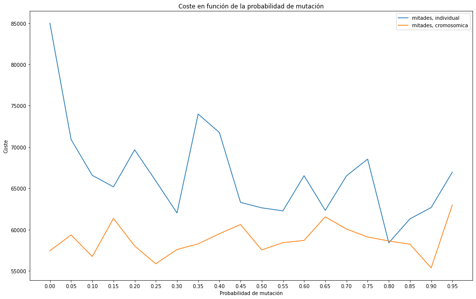

Como puede apreciarse, en términos generales, la mutación cromosómica tiende a generar resultados superiores en comparación con la mutación individual. En el caso de la mutación individual, se observa una marcada disminución a medida que aumenta la probabilidad de mutación, con picos tanto en los valores máximos como mínimos, alcanzando el mínimo absoluto con una probabilidad del 0,8. Por otro lado, en la mutación cromosómica, se nota que el costo se mantiene casi siempre alrededor de los 60 mil, registrándose los costos mínimos con probabilidades de 0,25 y 0,90.

Por esto, en el caso de utilizar mutación individual recomendaría una probabilidad de mutación del 0,80 mientras que con mutación cromosómica, si bien la probabilidad de 0,90 puede parecer demasiado alta, recomendaría esta o una probabilidad de 0,25.

**Pregunta 4**. Finalmente realiza un estudio variando el número de iteraciones máximas en el rango de 50 a 1000, considerando un paso variable o adaptativo a conveniencia. ¿Qué valor recomendarías para este parámetro? ¿Por qué? Realiza una discusión reflexionando sobre los resultados conjuntos de estos tres parámetros.

En esta última fase del análisis, exploramos el impacto de variar el número de iteraciones máximas en un rango amplio, específicamente de 50 a 1000, empleando un paso de 50 en 50. Esta variación permite evaluar cómo la convergencia del algoritmo genético se ve afectada por la duración de su ejecución. A continuación podemos observar una gráfica ejecutada con mutación individual y reemplazo en mitades.

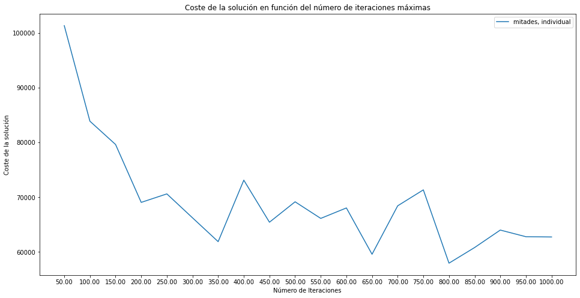

Se evidencia una disminución en el costo a medida que aumenta el número de iteraciones, especialmente en las fases iniciales. Un incremento en el número de iteraciones juega un papel crucial en la optimización de los costos, aunque esto conlleva un tiempo de ejecución prolongado, aunque la diferencia no es demasiado significativa.

En la consideración de esta variable, mi recomendación sería optar por 800 iteraciones, ya que este valor proporciona soluciones de mayor calidad en un tiempo de ejecución que se mantiene en niveles aceptables.

## Conclusión

Tras estudiar estas variables, se ha decidido que los mejores costos se deberían obtener con un tamaño de población de 64, utilizando el algoritmo de reemplazo en mitades, con mutación cromosómica de probabilidad 0,90 y con 800 iteraciones. Sabiendo esto, probamos cuál sería el resultado de usar todos los datos a la vez.